# Communicate Data Finding Project Udacity

# Analysis of Ford GoBike System Data

##### by ALI IRTAZA

## Introduction

Ford GoBike is a regional public bicycle sharing system in the San Francisco Bay Area, California. They began the operation in August 2013 as Bay Area Bike Share, the Ford GoBike system currently has over 2,600 bicycles in 262 stations across San Francisco, East Bay and San Jose. On June 28, 2017, the system officially launched as Ford GoBike in a partnership with Ford Motor Company.

# Data Wrangling

```python
# import all packages and set plots to be embedded inline
import numpy as np
import pandas as pd
import matplotlib.pyplot as plt
import seaborn as sb

%matplotlib inline
no_color = sb.color_palette()[0]
```

```python
df = pd.read_csv('C:\\Users\\Ali Irtaza\\Desktop\\Courses\\Udacity\\Data Analyst Nanodegree\\Projects\\Project 5 Communicate Data\\New folder (2)\\201904-fordgobike-tripdata.csv')
df.head()
```

|  | duration_sec | start_time | end_time | start_station_id | start_station_name | start_station_latitude | start_station_longitude | end_station_id | end_station_name | end_station_latitude | end_station_longitude | bike_id | user_type | bike_share_for_all_trip |
| --- | --- | --- | --- | --- | --- | --- | --- | --- | --- | --- | --- | --- | --- | --- |
| 0 | 50305 | 2019-04-30 22:33:55.1550 | 2019-05-01 12:32:20.4540 | 368.0 | Myrtle St at Polk St | 37.785434 | -122.419622 | 324.0 | Union Square (Powell St at Post St) | 37.788300 | -122.408531 | 2749 | Subscriber | No |
| 1 | 53725 | 2019-04-30 20:43:41.6320 | 2019-05-01 11:39:06.9170 | 246.0 | Berkeley Civic Center | 37.869060 | -122.270556 | 241.0 | Ashby BART Station | 37.852477 | -122.270213 | 2608 | Customer | No |
| 2 | 78072 | 2019-04-30 10:32:46.4890 | 2019-05-01 08:13:58.9750 | 64.0 | 5th St at Brannan St | 37.776754 | -122.399018 | 64.0 | 5th St at Brannan St | 37.776754 | -122.399018 | 258 | Subscriber | No |
| 3 | 78969 | 2019-04-30 10:00:51.5500 | 2019-05-01 07:57:01.2620 | 67.0 | San Francisco Caltrain Station 2 (Townsend St... | 37.776639 | -122.395526 | 89.0 | Division St at Potrero Ave | 37.769218 | -122.407646 | 1974 | Subscriber | No |
| 4 | 1128 | 2019-04-30 23:59:04.7390 | 2019-05-01 00:17:53.0910 | 124.0 | 19th St at Florida St | 37.760447 | -122.410807 | 5.0 | Powell St BART Station (Market St at 5th St) | 37.783899 | -122.408445 | 877 | Subscriber | No |

```python
df.info()
```

```
<class 'pandas.core.frame.DataFrame'>
RangeIndex: 239111 entries, 0 to 239110
Data columns (total 14 columns):
 #   Column                   Non-Null Count   Dtype
---  ------                   --------------   -----
 0   duration_sec             239111 non-null  int64
 1   start_time               239111 non-null  object
 2   end_time                 239111 non-null  object
 3   start_station_id         239047 non-null  float64
 4   start_station_name       239047 non-null  object
 5   start_station_latitude   239111 non-null  float64
 6   start_station_longitude  239111 non-null  float64
 7   end_station_id           239047 non-null  float64
 8   end_station_name         239047 non-null  object
 9   end_station_latitude     239111 non-null  float64
 10  end_station_longitude    239111 non-null  float64
 11  bike_id                  239111 non-null  int64
 12  user_type                239111 non-null  object
 13  bike_share_for_all_trip  239111 non-null  object
dtypes: float64(6), int64(2), object(6)
memory usage: 25.5+ MB
```

```python
df.describe()
```

|  | duration_sec | start_station_id | start_station_latitude | start_station_longitude | end_station_id | end_station_latitude | end_station_longitude | bike_id |
| --- | --- | --- | --- | --- | --- | --- | --- | --- |
| count | 239111.000000 | 239047.000000 | 239111.000000 | 239111.000000 | 239047.000000 | 239111.000000 | 239111.000000 | 239111.000000 |
| mean | 802.671199 | 141.836538 | 37.769536 | -122.352503 | 140.838099 | 37.766996 | -122.343420 | 3666.956493 |
| std | 1990.006091 | 116.289776 | 0.127698 | 0.277088 | 116.386168 | 0.343083 | 1.068144 | 2180.717333 |
| min | 61.000000 | 3.000000 | 0.000000 | -122.453704 | 3.000000 | 0.000000 | -122.453704 | 11.000000 |
| 25% | 349.000000 | 47.000000 | 37.770083 | -122.413004 | 44.000000 | 37.770407 | -122.411738 | 1720.000000 |
| 50% | 558.000000 | 104.000000 | 37.780760 | -122.398285 | 102.000000 | 37.780955 | -122.397437 | 3471.000000 |
| 75% | 876.000000 | 240.000000 | 37.797280 | -122.291209 | 239.000000 | 37.797320 | -122.291376 | 5749.000000 |
| max | 86114.000000 | 420.000000 | 37.880222 | 0.000000 | 420.000000 | 37.880222 | 0.000000 | 7108.000000 |

### What is the structure of your dataset?

The dataset has 239047 bike rides that happen in 2019 in the San Francisco Bay Area. The dataset contained features about:

> - trip duration: how long the trip took in seconds
> - start time/end time: start/end date/time for the bike rides.
> - stations: start/end station, name, geolocation (latitude/longitude)
> - User type
> - rented bikes: bike id

The dataset was further enhanced with features that I may find neccessary to perform interesting analysis:

> - rental time: hour of the day, weekday

### What is/are the main feature(s) of interest in your dataset?

I am interested in investigate duration of biking time.

### What features in the dataset do you think will help support your investigation into your feature(s) of interest?

I think the following features may help to support my investigation into the feature (duration) I am interested.

> - start_time - I'll extract dayofweek, hours for further investigation.
> - user_type

## Univariate Exploration

**Converting duration to minutes instead of seconds for so that investigation can be easy.**

```python
df_clean['duration_min'] = df_clean['duration_sec']/60
df_clean.info()
```

```
<class 'pandas.core.frame.DataFrame'>
Int64Index: 239047 entries, 0 to 239110
Data columns (total 17 columns):
 #   Column                   Non-Null Count   Dtype
---  ------                   --------------   -----
 0   duration_sec             239047 non-null  int64
 1   start_time               239047 non-null  datetime64[ns]
 2   end_time                 239047 non-null  datetime64[ns]
 3   start_station_id         239047 non-null  float64
 4   start_station_name       239047 non-null  object
 5   start_station_latitude   239047 non-null  float64
 6   start_station_longitude  239047 non-null  float64
 7   end_station_id           239047 non-null  float64
 8   end_station_name         239047 non-null  object
 9   end_station_latitude     239047 non-null  float64
 10  end_station_longitude    239047 non-null  float64
 11  bike_id                  239047 non-null  int64
 12  user_type                239047 non-null  object
 13  bike_share_for_all_trip  239047 non-null  object
 14  start_time_dayofweek     239047 non-null  category
 15  start_time_hour          239047 non-null  int64
 16  duration_min             239047 non-null  float64
dtypes: category(1), datetime64[ns](2), float64(7), int64(3), object(4)
memory usage: 31.2+ MB
```

[output not shown]

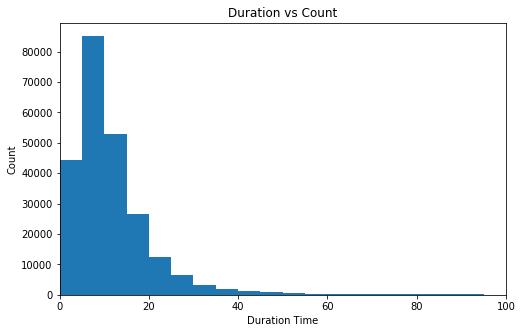

```python
bins = np.arange(0, df_clean['duration_min'].max()+5, 5)

plt.figure(figsize=[8, 5])

plt.hist(data = df_clean, x = 'duration_min', bins=bins);
plt.xlim(0,100);
plt.xlabel('Duration Time');
plt.ylabel('Count');
plt.title('Duration vs Count');
```

From the above histogram we can observe: Most of the data is below 50 minutes. The distribution seems to be rightly skewed.

**The data is not distributed normally. Let's calculate of IQR:**

> - IQR = Q3 - Q1 = 14.6 - 5.816
> - Upper Wisker Bound = (1.5 * IQR) + Q3 = 13.176 + 14.6 = 27.776

[figure not shown]

```python
bins = 10 ** np.arange(0, np.log10(df_clean['duration_min'].max())+0.025, 0.025)

plt.figure(figsize=[8, 5]);
plt.hist(data = df_clean, x = 'duration_min', bins = bins);
plt.xscale('log');
plt.xticks([1, 2, 5, 10, 20, 50, 100, 200, 500, 1000, 2000], [1, 2, 5, 10, 20, 50, 100, 200, 500, 1000, 2000]);
plt.xlabel('Duration (min)');
plt.ylabel('Count');
plt.title('Time Duration vs Count');
```

The data is somehow right skewed, so let's put it on a log scale instead

[figure not shown]

```python
bins = 10 ** np.arange(0, np.log10(df_clean['duration_min'].max())+0.025, 0.025)

plt.figure(figsize=[8, 5]);
plt.hist(data = df_clean, x = 'duration_min', bins = bins);
plt.xscale('log');
plt.xticks([1, 2, 5, 10, 20, 50, 100, 200, 500, 1000, 2000], [1, 2, 5, 10, 20, 50, 100, 200, 500, 1000, 2000]);
plt.xlabel('Duration (min)');
plt.ylabel('Count');
plt.title('Time Duration vs Count');
```

Now the distribution now looks closer to normal distribution. But, there is a long tail still. Let's remove the long tail.

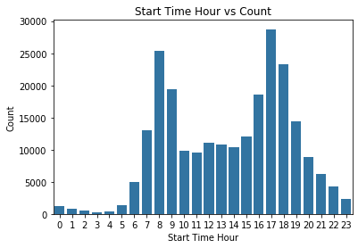

```python
sb.countplot(data = df_clean, x = 'start_time_hour', color = no_color);
plt.xlabel('Start Time Hour');
plt.ylabel('Count');
plt.title('Start Time Hour vs Count');
```

8:00 AM and 5:00 PM are the two peak hours which have most bikers

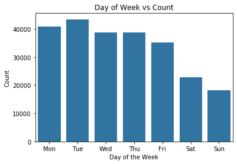

```python
sb.countplot(data = df_clean, x = 'start_time_dayofweek', color = no_color);
plt.xlabel('Day of the Week');
plt.ylabel('Count');
plt.title('Day of Week vs Count');
```

It is clear from above visual that Tuesday has most bikers.

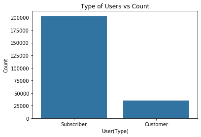

```python
sb.countplot(data = df_clean, x = 'user_type', color = no_color);
plt.xlabel('User(Type)');
plt.ylabel('Count');
plt.title('Type of Users vs Count');
```

There are more 'Subscriber' users than 'Customer' users

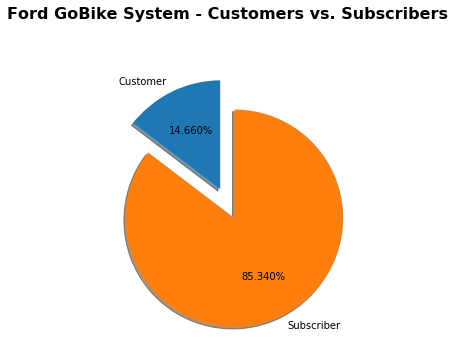

```python
customer = df_clean.query('user_type == "Customer"')['bike_id'].count()
subscriber = df_clean.query('user_type == "Subscriber"')['bike_id'].count()
customer_prop = customer / df_clean['bike_id'].count()
subscriber_prop = subscriber / df_clean['bike_id'].count()

# pie chart
plt.figure(figsize = [8, 5])

labels = ['Customer', 'Subscriber']
size = [customer_prop, subscriber_prop]
explode = (0, 0.3)

plt.pie(size, explode=explode, labels = labels, autopct='%1.3f%%', shadow=True, startangle=90, textprops={'color':'black'})
plt.axis('equal')

plt.suptitle('Ford GoBike System - Customers vs. Subscribers', y=1.05, fontsize=16, fontweight='bold');
```

The pie chart shows: About approx. 85.0% of bikers are Subscriber users and 15.0% of bikers are Customer users.

## Bivariate Exploration

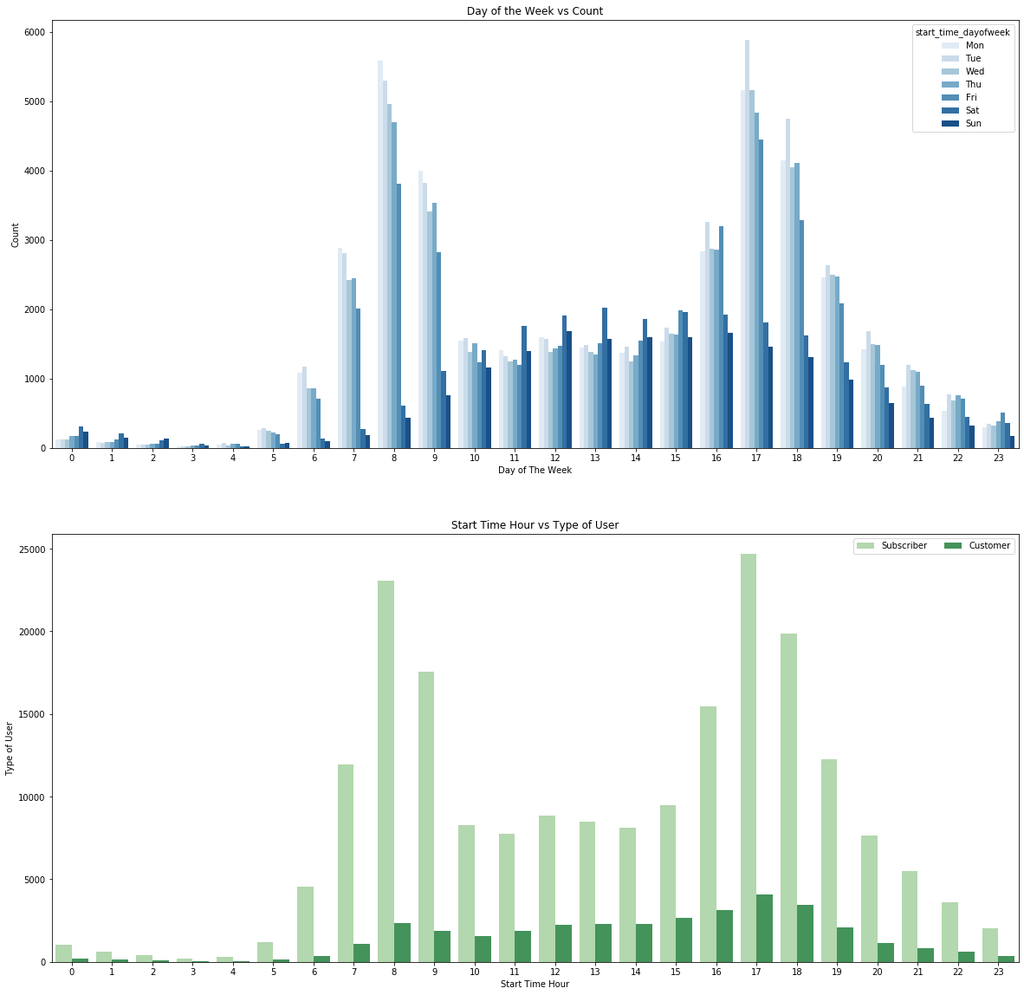

```python
plt.figure(figsize = [20, 20]);


plt.subplot(2, 1, 1);
sb.countplot(data = df_clean, x = 'start_time_hour', hue = 'start_time_dayofweek', palette = 'Blues');
plt.xlabel('Day of The Week');
plt.ylabel('Count');
plt.title('Day of the Week vs Count');


ax = plt.subplot(2, 1, 2);
sb.countplot(data = df_clean, x = 'start_time_hour', hue = 'user_type', palette = 'Greens');
ax.legend(loc = 1, ncol = 2); # re-arrange legend to remove overlapping
plt.xlabel('Start Time Hour');
plt.ylabel('Type of User');
plt.title('Start Time Hour vs Type of User');
```

Observations from above plots: Tuesday, 5:00 PM has the highest biker counts across 7 days, 24 hours. 5:00 PM has the most 'Subscriber' bikers compared to other hours. It also has the most 'Customer' bikers compared to other hours.

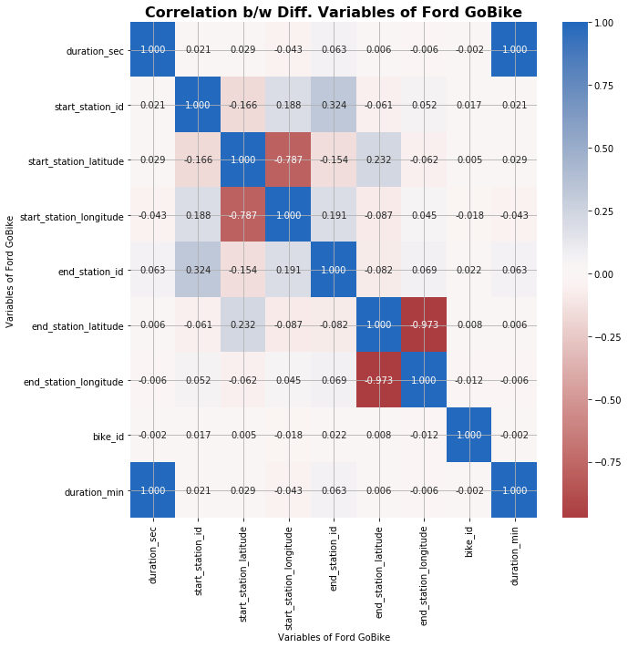

```python
plt.figure(figsize = [10, 10])
sb.heatmap(df_clean[all_numeric_vars].corr(), annot = True, fmt = '.3f', cmap = 'vlag_r', center = 0);
plt.title('Correlation b/w Diff. Variables of Ford GoBike', y=1.05, fontsize=16, fontweight='bold')
plt.xlabel('Variables of Ford GoBike')
plt.ylabel('Variables of Ford GoBike');
plt.grid()
```

### Ford GoBike System Trends by User Type

The below point plot below is an excellent graphical visual that shwows the sharp contrast between Customers and Subscribers. Customers have a relatively low usage of the bike share system with a small increase on the weekends. Subscribers are the opposite - there is steadily high usage on weekdays, with a sharp decline on the weekend.

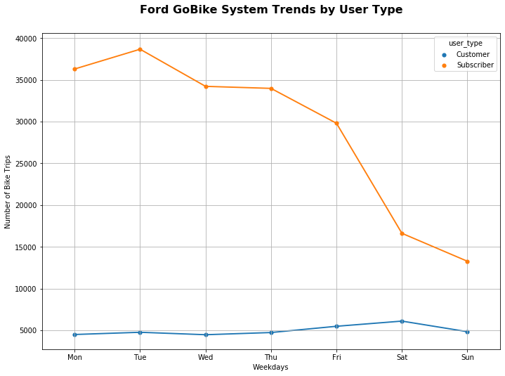

```python
# Customer Usage by Weekday vs. Subscriber Usage by Weekday
plt.figure(figsize=[ 11.69, 8.27]);

df_cleaned_user_week = df_clean.groupby(['start_time_dayofweek', 'user_type']).size().reset_index()
weekday = ['Mon', 'Tue', 'Wed', 'Thu', 'Fri', 'Sat', 'Sun']

ax = sb.pointplot(data=df_cleaned_user_week, x='start_time_dayofweek', y=0, hue = 'user_type', scale=.7, order = weekday);

plt.title('Ford GoBike System Trends by User Type', y=1.05, fontsize=16, fontweight='bold')
plt.xlabel('Weekdays')
plt.ylabel('Number of Bike Trips');
plt.grid()
```

**Summary of all Observations from above plots:**

> - Tuesday, 5:00 PM has the highest biker counts across 7 days, 24 hours.
> - 5:00 PM has the most 'Subscriber' bikers compared to other hours. It also has the most 'Customer' bikers compared to other hours.
> - Tuesday has the most 'Subscriber' bikers compared to other days. Saturday has the most 'Customer' bikers compared to other days.

### Ford Go Bike System - Duration (Min) by User Type

###### Oberservation

The catplot show the ride duration spread in minutes. The duration of Customer are greater (8 to 18 minutes according to the plot) than for subscribers (5 to 12 minutes according to the box plot). This can be concluded from the plot that subscribers are mainly who take short trips to work/school rather than longer trips around the Bay Area.

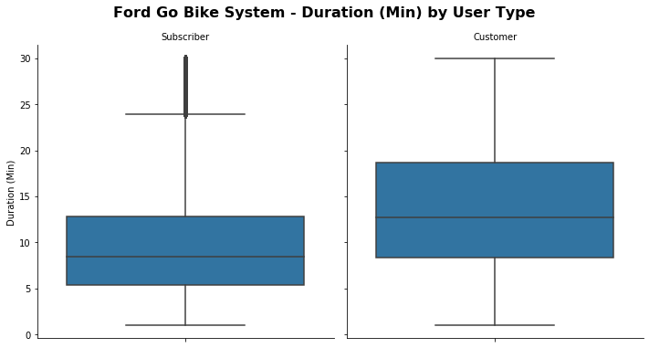

```python
plt.figure(figsize=[11.69, 8.27]);

data = df_clean.query('duration_min < 30')

g = sb.catplot(data=data, y='duration_min', col="user_type", kind='box', color = no_color);

g.set_titles(col_template = '{col_name}');
g.set_axis_labels("", "Duration (Min)");
g.fig.suptitle('Ford Go Bike System - Duration (Min) by User Type', y=1.05, fontsize=16, fontweight='bold');
```

### Did you observe any interesting relationships between the other features (not the main feature(s) of interest)?

Observations from above plots:

> - Tuesday, 5:00 PM has the highest biker counts across 7 days, 24 hours.
> - 5:00 PM has the most 'Subscriber' bikers compared to other hours. It also has the most 'Customer' bikers compared to other hours.
> - Tuesday has the most 'Subscriber' bikers compared to other days. Saturday has the most 'Customer' bikers compared to other days.

## Multivariate Exploration

### Ford GoBike System - Start Time vs. Weekday by User Type

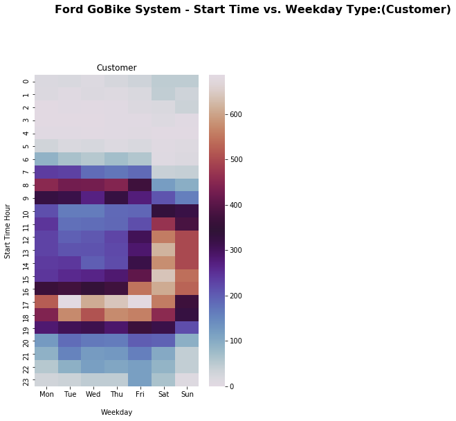

```python
# Weekday order
weekday = ['Mon', 'Tue', 'Wed', 'Thu', 'Fri', 'Sat', 'Sun']
df_clean['start_time_dayofweek'] = pd.Categorical(df_clean['start_time_dayofweek'], categories= ['Mon', 'Tue', 'Wed', 'Thu', 'Fri', 'Sat', 'Sun'], ordered=True);

plt.figure(figsize=[11.69, 8.27]);

# Heatmap of Customers
plt.subplot(1, 2, 1)
df_customer = df_clean.query('user_type == "Customer"').groupby(['start_time_hour', 'start_time_dayofweek'])['bike_id'].size().reset_index();
df_customer = df_customer.pivot('start_time_hour', 'start_time_dayofweek', 'bike_id')
sb.heatmap(df_customer, cmap = 'twilight')

plt.title('Customer', y=1.05)
plt.xlabel('Weekday', labelpad = 16)
plt.ylabel('Start Time Hour',  labelpad = 16)
plt.suptitle('Ford GoBike System - Start Time vs. Weekday Type:(Customer)', y = 1.05, fontsize = 16, fontweight = 'bold');
```

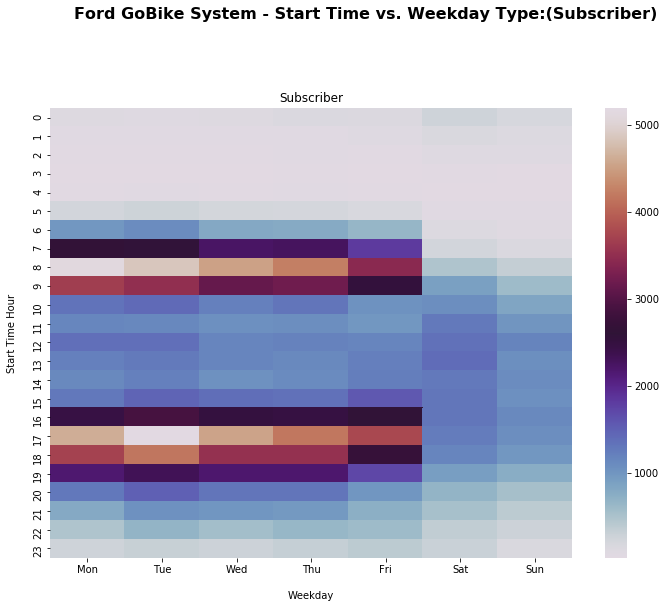

```python
# Heatmap of Subscribers
plt.figure(figsize=[11.69, 8.27]);
df_subscriber = df_clean.query('user_type == "Subscriber"').groupby(['start_time_hour', 'start_time_dayofweek'])['bike_id'].size().reset_index();
df_subscriber = df_subscriber.pivot('start_time_hour', 'start_time_dayofweek', 'bike_id')
sb.heatmap(df_subscriber, cmap = 'twilight')

plt.title("Subscriber", y=1.05)
plt.xlabel('Weekday', labelpad = 16)
plt.ylabel('Start Time Hour', labelpad = 16);

plt.suptitle('Ford GoBike System - Start Time vs. Weekday Type:(Subscriber)', y = 1.05, fontsize = 16, fontweight = 'bold');
```

### Oberservation from above:

How does the average trip duration vary in weekdays between customers and subscribers?

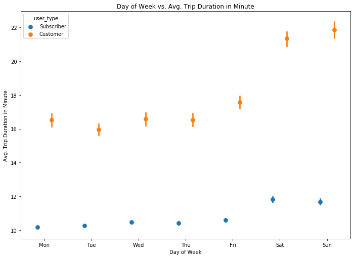

```python
plt.figure(figsize=[11.69, 8.27]);
sb.pointplot(data=df_clean, x='start_time_dayofweek', y='duration_min', hue='user_type', dodge=0.3, linestyles="");
plt.xlabel('Day of Week');
plt.ylabel('Avg. Trip Duration in Minute');
plt.title('Day of Week vs. Avg. Trip Duration in Minute')
```

#### Observation from above:

We can see from the above plot that endorsers ride a lot shorter/faster outings contrasted with clients on every day of the week. Both client types have an expansion of outing span on ends of the week i.e Saturday and Sunday, particularly for easygoing riders. Endorsers use is by all accounts more effective than clients generally speaking and kept up a steady normal length Monday through Friday.

**How does the hourly usage vary during weekdays for customers and subscribers?**

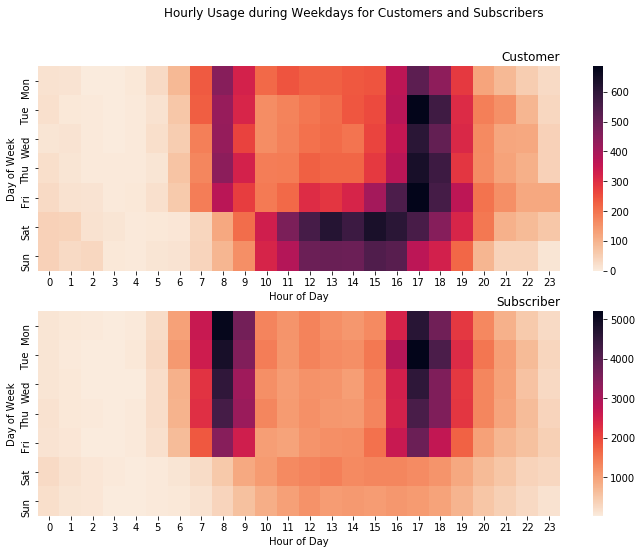

```python
plt.figure(figsize=[11.69, 8.27]);
plt.subplot(2, 1, 1)
customers = df_clean.query('user_type == "Customer"')
ct_counts = customers.groupby(['start_time_dayofweek', 'start_time_hour']).size()
ct_counts = ct_counts.reset_index(name='count')
ct_counts = ct_counts.pivot(index='start_time_dayofweek', columns='start_time_hour', values='count')
sb.heatmap(ct_counts, cmap='rocket_r');
plt.title('Customer', loc='right');
plt.xlabel('Hour of Day');
plt.ylabel('Day of Week');

plt.subplot(2, 1, 2)
subscribers = df_clean.query('user_type == "Subscriber"')
st_counts = subscribers.groupby(['start_time_dayofweek', 'start_time_hour']).size()
st_counts = st_counts.reset_index(name='count')
st_counts = st_counts.pivot(index='start_time_dayofweek', columns='start_time_hour', values='count')
sb.heatmap(st_counts, cmap='rocket_r');
plt.title('Subscriber', loc='right');
plt.xlabel('Hour of Day');
plt.ylabel('Day of Week');
plt.suptitle('Hourly Usage during Weekdays for Customers and Subscribers')
```

# Ford GoBike System - Summary

Following is the short summary that we can summarize from this project:

> The Ford GoBike Sytem is a Naturally neighborly, spending benevolent, and lifetsyle agreeable.

> The user type subscribers are those who use this daily is a benefit from a healthy life.

> The second user type is Customers, they have a maintained and very flexible and better option for touring the city according to there availability.

> The system is very affordable and convenient for all types of classes

> Leasing a bicycle from theFord GoBike System is a fabulous (solid and ecologically inviting) method of moving around in the city, both for pleasure and work.

### The most interesting interaction between feature:

The most interesting interaction between features were the Customers and Subscribers,where there was major difference between their time duration and Day of the Week they use the bike.